# Week 2 Milestone Report

Eric Oden

September 12, 2021

## Introduction

This milestone report presents an exploratory analysis of the data provided for the Natural Language Processing (NPL) capstone project from the Coursera Johns Hopkins Data Science Specialization. The ultimate goal of the project is to develop a user-friendly Shiny app for text prediction. To develop the prediction model, a data set of text files is provided by the company [Swiftkey](https://www.microsoft.com/en-us/swiftkey?activetab=pivot_1%3aprimaryr2). The data is a corpus of blog, news, and twitter text in English, German, Finnish, and Russian. In this report, we shall perform a basic summary of the English-language data, as well as a study of the $N$-gram frequency. Finally, we shall outline the plan to use the data for our prediction algorithm.

## Exploratory Analysis

The [data set](https://d396qusza40orc.cloudfront.net/dsscapstone/dataset/Coursera-SwiftKey.zip) is downloaded from the Coursera page. The files associated with English-language blogs, news, and tweets are then read into memory. The corresponding code is included in Appendix A.

### Basic Summary

We start our exploration by peeking at the files themselves, as well as computing global statistics about the data (file size, line counts, etc.).

#### Manual Inspection

Reading the first couple lines of the blogs file:

```
## [1] "In the years thereafter, most of the Oil fields and platforms were named after pagan “gods”."
## [2] "We love you Mr. Brown."
```

the news file:

```
## [1] "He wasn't home alone, apparently."
## [2] "The St. Louis plant had to close. It would die of old age. Workers had been making cars there since the onset of mass automotive production in the 1920s."
```

and the twitter file:

```
## [1] "How are you? Btw thanks for the RT. You gonna be in DC anytime soon? Love to see you. Been way, way too long."
## [2] "When you meet someone special... you'll know. Your heart will beat more rapidly and you'll smile for no reason."
```

The text in the lines appear to indeed stem from the corresponding sources. Looking at several other lines of each, tweets tend to use a stream-of-consciousness or conversational tone, using incomplete sentences, stump words (e.g., “Fri”, “Cali”), misspellings and internet slang (e.g., “ya ik”, “time 4 lunch”). Meanwhile, news and blogs text generally observe the rules of grammar and proper spelling, with the main four writing styles (persuasive, narrative, expository, and descriptive) appearing in the blog text, while the news files are primarily expository. We observe that the lines of text include all capital and lower case letters, numbers, punctuation (including nonstandard, like double exclamation marks), miscellaneous symbols (*, ~, |, #, etc.), URLS, twitter handles, email addresses, emoticons, and emojis. We will need to take these variations into account when we prepare our model.

#### Global Statistics

We now summarize each file. In particular, we measure the file size (in [mebibytes](https://en.wikipedia.org/wiki/Byte#Multiple-byte_units)), number of lines, number of words, number of characters, mean words per line (WPL), mean characters per word (CPW), and maximum characters per line (CPL).

|  | File | Size | Lines | Words | Characters | MeanWPL | MeanCPW | MaxCPL |
| --- | --- | --- | --- | --- | --- | --- | --- | --- |
| blogs | en_US.blogs.txt | 200 MiB | 899288 | 37570839 | 206824505 | 41.8 | 5.5 | 40833 |
| news | en_US.news.txt | 196 MiB | 77259 | 2651432 | 15639408 | 34.6 | 5.8 | 5760 |
| twitter | en_US.twitter.txt | 159 MiB | 2360148 | 30451170 | 162096241 | 12.8 | 5.4 | 140 |

The code to produce the table is in Appendix B. The files are each quite large (for reference, 200 MiB is about 22 minutes of uncompressed audio). We observe that blog lines are the most verbose on average, followed by new lines, then tweets. The news lines have the greatest number of characters per word, followed by the blog lines, then tweets. Meanwhile, there are far more lines of twitter text than blogs or news text. We finally hypothesize the twitter text comes from samples taken before November 8, 2017, when twitter doubled the character limit to 280.

### $N$-gram Analysis

A central structure in the NLP literature is the $N$-gram: “a contiguous sequence of *n* items from a given sample of text or speech.” We shall investigate the frequency of the 1-grams (unigrams), 2-grams (bigrams), and 3-grams (trigrams) in our data set, where an “item” is a word.

#### Subsetting and Cleaning

However, because the files are quite large, and because identifying $N$-gram counts is a computationally expensive process, we shall select a smaller subset for our analysis. In particular, we shall sample (without replacement) 1% of the lines from each of the three files. We’ll then combine the resulting subsets into a single set on which we’ll perform our analysis. While the blogs, news, and twitter files are 200 MiB, 196 MiB and 159 MiB, respectively, the sampled data is only 5.9 MiB. The code to perform this subsetting and aggregating is in Appendix C.

Next, we shall clean this smaller data set. We shall perform the following steps:

- remove URLs, email addresses, twitter handles, and hash tags
- remove punctuation marks
- remove numbers
- convert all letters to lowercase
- trim white space
- remove profanity

The code to perform this processing is in Appendix D.

We should note that a common step in NPL is to remove stop words (highly frequently used words which provide little information, like “the”, “is”, etc.). However, because our goal is to predict text, these should be kept since, by definition, a user will frequently intend to type a stop word.

Regarding profanity. A user may well intend to write a bad word, and removing such text from our data restricts our ability to predict it. However, between a capacity to predict profane language and avoiding suggesting bad words to children and those upset by them (a group of which I am a card-carrying member), the latter is preferable. To this end, we use a [fairly popular list](https://github.com/LDNOOBW/List-of-Dirty-Naughty-Obscene-and-Otherwise-Bad-Words) (SFW), found on Github.

#### Frequency Study

We now tokenize the text into unigrams, bigrams, and trigrams, and for each type of token, visualize the top 20 most frequently appearing in the corpus:

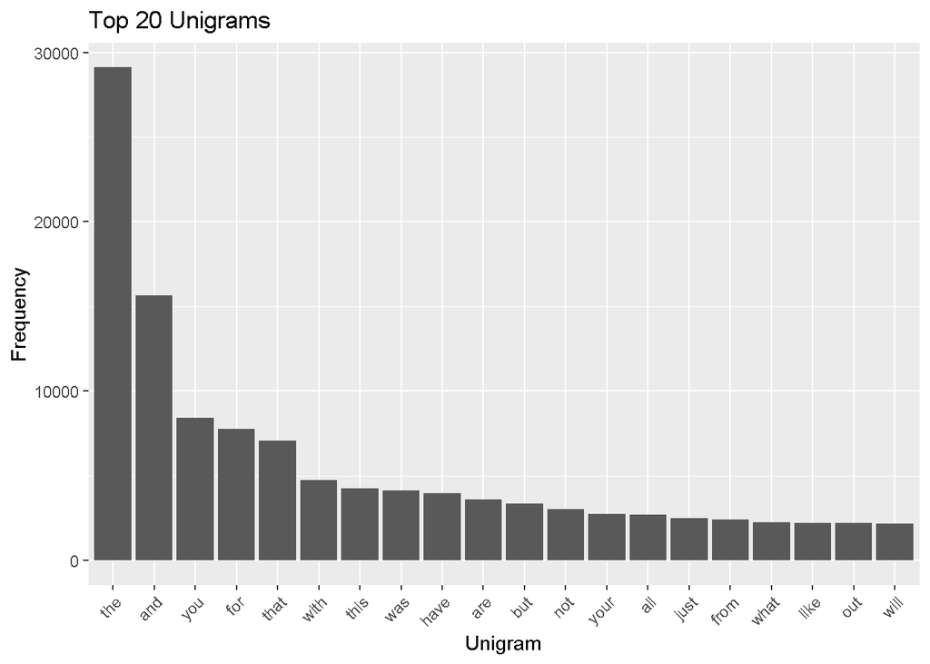

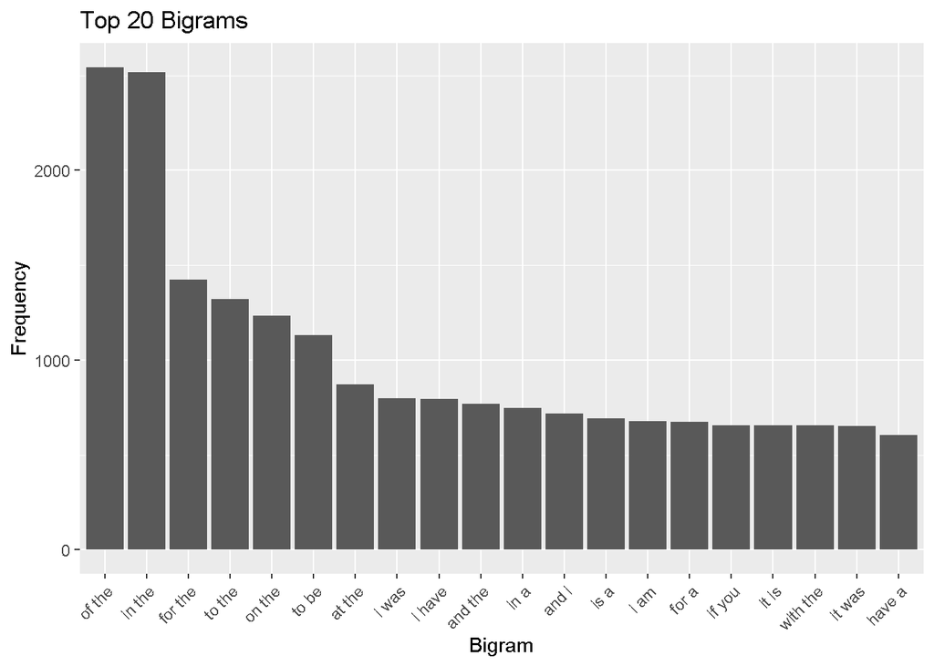

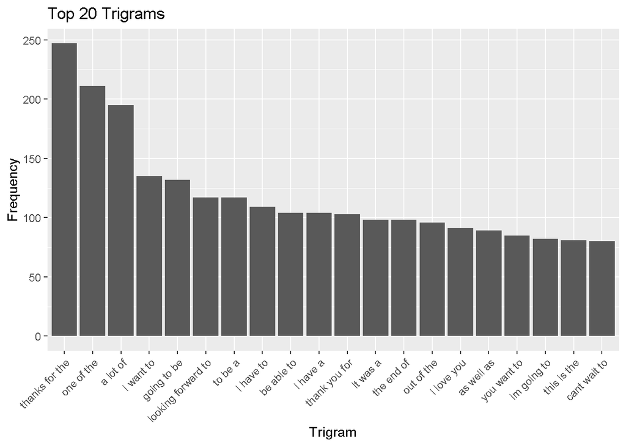

The code to create these plots is in Appendix E. In the first plot, we observe [Zipf’s law](https://en.wikipedia.org/wiki/Zipf%27s_law) in action: the most frequent word, “the”, is used roughly twice as frequently as the second most frequent word, “and”, and roughly three times as frequently as the third most frequent word, “you”.

We may be able to exploit Zipf’s law. If the majority of word instances are only in a (relatively) small dictionary of words, we may be able to train our model on a significantly smaller set. We can create a plot of the coverage of all unigram instances in the corpus versus the number of unigrams in a frequency sorted dictionary:

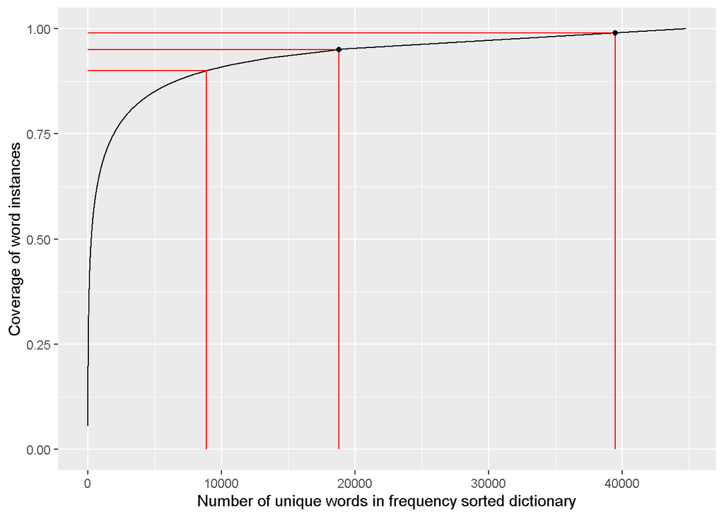

The code for this plot is in Appendix F. We observe 8873 words represent 90% of all word instances, 18776 words represent 95% and 39458 words represent 99%. This plot indicates we may be able to use a significantly smaller subset of our data (i.e., the most frequent unigrams, bigrams, etc.) without sacrificing modeling strength.

## Next steps

Having performed some exploratory analysis, we can now outline the plan for building the prediction model.

- First, apply a Markov assumption: suppose the probability of the next word in a sequence depends only on a limited history of preceding words. Supposing further that it only depends on the previous word, the probability of word $w_n$ depends only on word $w_{n-1}$:
  $$P(w_n \mid w_{n-1}, w_{n-2}, \dots, w_1) =
  P(w_n \mid w_{n-1}).$$
- We can then calculate the probabilities in the following way:
  $$P(w_n \mid w_{n-1}) =
  \frac{\text{Count}(w_{n-1}w_n)}{\text{Count}(w_{n-1})},$$
  where $\text{Count}(w_{n-1}w_n)$ is the number of instances of the bigram $w_{n-1}w_n$ in the corpus, and $\text{Count}(w_{n-1})$ is the number of instances of the unigram $w_{n-1}$ in the corpus.
- A similar process can be performed with trigrams, quadrigrams, etc. (we’d expect better predictions by doing so). However, this quickly becomes computationally expensive. Furthermore, $N$-grams where $N>4$, even for our fairly large data set, will likely be fairly sparse, since the probability of a given sequence of words drops precipitously with additional words.
- Basic $N$-gram models such as the above struggle with rare sequences of words. In order to handle this, we can apply a method like [Good-Turing Smoothing](https://www.cs.cornell.edu/courses/cs6740/2010sp/guides/lec11.pdf), which (intelligently) shifts some of the probability mass to unseen sequences.
- Another avenue is use a linear combination of unigram, bigram, and & trigram probabilities (i.e., using a so called ``finite-mixture model’’):
  $$P(w_n \mid w_{n-2}w_{n-1}) = \lambda_3 P(w_n \mid w_{n-2} w_{n-1}) + \lambda_2 P(w_n |
  w_{n-1}) + \lambda_1 P(w_n).$$
- Another still is [Katz’s back-off model](https://en.wikipedia.org/wiki/Katz%27s_back-off_model), which uses the highest order $N$-gram probabilities available.

Altogether, there are a number of methods we can apply to create a successful $N$-gram model from our data. We shall use the standard machine learning techniques of model validation/parameter tuning to arrive at a model with the highest accuracy we can.

## Appendix

### A

Downloading and reading the text files

```r
DATA_URL <- 'https://d396qusza40orc.cloudfront.net/dsscapstone/dataset/'
FILE_NAME <- 'Coursera-SwiftKey.zip'

if (!file.exists('data')) {
    dir.create('data')
}

if (!file.exists('data/final')) {
    temp_file <- tempfile()
    download.file(paste0(DATA_URL, FILE_NAME), temp_file)
    unzip(temp_file, exdir = 'data')
    unlink(temp_file)
}

read_file <- function(file_name) {
    con <- file(file_name, open = 'r')
    on.exit(close(con))
    readLines(con, encoding = "UTF-8", skipNul = TRUE, warn = FALSE)
}

dir <- './data/final/en_US/'
blogs_file <- paste0(dir, 'en_US.blogs.txt')
news_file <- paste0(dir, 'en_US.news.txt')
twitter_file <- paste0(dir, 'en_US.twitter.txt')

blogs <- read_file(blogs_file)
news <- read_file(news_file)
twitter <- read_file(twitter_file)
```

### B

Creating the data summary table

```r
file_size <- sapply(list(blogs_file, news_file, twitter_file),
                    function(x) round(file.info(x)$size / 1024 ^ 2))

num_lines <- sapply(list(blogs, news, twitter), length)

num_words <- sapply(list(blogs, news, twitter), stri_stats_latex)[4,]

num_chars <- sapply(list(blogs, news, twitter),
                    function (x) sum(nchar(x)))

wpl <- lapply(list(blogs, news, twitter), function(x) stri_count_words(x))
names(wpl) <- c('blogs', 'news', 'twitter')

mean_wpl <- sapply(wpl, mean)

cpl <- lapply(list(blogs, news, twitter), function(x) nchar(x))
names(cpl) <- c('blogs', 'news', 'twitter')

mean_cpl <- sapply(cpl, mean)

mean_cpw <- mean_cpl / mean_wpl

max_cpl <- sapply(cpl, max)

summary <- data.frame(
    File = c('en_US.blogs.txt', 'en_US.news.txt', 'en_US.twitter.txt'),
    Size = paste(file_size , 'MiB'),
    Lines = num_lines,
    Words = num_words,
    Characters = num_chars,
    MeanWPL = round(mean_wpl, 1),
    MeanCPW = round(mean_cpw, 1),
    MaxCPL = round(max_cpl),
    row.names = c("blogs", "news", "twitter")
)

kable(summary) %>% kable_styling(position = "left")
```

### C

Subsetting the text

```r
get_subset <- function (text) {
    name <- deparse(substitute(text))
    sample(text, size = summary[name, 'Lines'] * 0.01, replace = FALSE)
}

blogs_subset <- get_subset(blogs)

news_subset <- get_subset(news)

twitter_subset <- get_subset(twitter)

en_subset <- c(blogs_subset, news_subset, twitter_subset)

# clear up memory
rm(blogs, news, twitter)
rm(cpl, wpl)
rm(blogs_subset, news_subset, twitter_subset)
```

### D

Processing the subsetted text. We use the [`tm`](https://cran.r-project.org/web/packages/tm/) package to process our subset into a corpus.

```r
en_corpus <- VCorpus(VectorSource(en_subset))

removePattern <- content_transformer(function(x, pattern) gsub(pattern, "", x))

en_corpus <- tm_map(en_corpus, removePattern, "(f|ht)tp(s?)://\\S+")
en_corpus <- tm_map(en_corpus, removePattern,
                    "[[:alnum:]\\.-]+@[[:alnum:].[:alnum:]]+")
en_corpus <- tm_map(en_corpus, removePattern, "@\\S+")
en_corpus <- tm_map(en_corpus, removePattern, "#\\S+")
en_corpus <- tm_map(en_corpus, removePattern, "-")
en_corpus <- tm_map(en_corpus, content_transformer(removePunctuation))
en_corpus <- tm_map(en_corpus, content_transformer(removeNumbers))
en_corpus <- tm_map(en_corpus, content_transformer(tolower))
en_corpus <- tm_map(en_corpus, content_transformer(stripWhitespace))

# download bad word file
URL <- 'https://raw.githubusercontent.com/LDNOOBW/List-of-Dirty-Naughty-Obscene-and-Otherwise-Bad-Words/master/en'
if (!file.exists('data/bad_words.csv')) {
    download.file(URL, 'data/bad_words.csv')
}
bad_words <- readLines('./data/bad_words.csv')

# remove bad words
removeBadWords <- content_transformer(function(x) removeWords(x, bad_words))
en_corpus <- tm_map(en_corpus, removeBadWords)
```

### E

Plotting the unigram, bigram, and trigram frequencies

```r
UnigramTokenizer <-
    function(x) unlist(lapply(ngrams(words(x), 1), paste, collapse = " "))

BigramTokenizer <-
    function(x) unlist(lapply(ngrams(words(x), 2), paste, collapse = " "), use.names = FALSE)

TrigramTokenizer <-
    function(x) unlist(lapply(ngrams(words(x), 3), paste, collapse = " "), use.names = FALSE)

getFreq <- function(tdm) {
    freq <- sort(row_sums(tdm), decreasing = TRUE)
    return(data.frame(word = names(freq), freq = freq, row.names = NULL))
}

plotFreq <- function(df, label){
    ggplot(df[1:20,], aes(x = reorder(word, -freq), y = freq)) +
    geom_bar(stat = "identity") +
    theme(axis.text.x = element_text(angle = 45, hjust = 1)) +
        labs(x = label, y = "Frequency", title = paste0("Top 20 ", label, "s"))
}

en_corpus %>%
    TermDocumentMatrix(control = list(tokenize = UnigramTokenizer)) %>%
    getFreq() %>%
    plotFreq("Unigram")

en_corpus %>%
    TermDocumentMatrix(control = list(tokenize = BigramTokenizer)) %>%
    getFreq() %>%
    plotFreq("Bigram")

en_corpus %>%
    TermDocumentMatrix(control = list(tokenize = TrigramTokenizer)) %>%
    getFreq() %>%
    plotFreq("Trigram")
```

### F

Plotting the word coverage

```r
unigram_tdm <- TermDocumentMatrix(en_corpus,
                                  control = list(tokenize = UnigramTokenizer))
unigram_freq <- row_sums(unigram_tdm)
num_words <- sum(unigram_freq)
sorted_unigram_freq <- sort(unigram_freq, decreasing = TRUE)
coverage <- cumsum(sorted_unigram_freq) / num_words
df <- as.data.frame(coverage)
df$index <- 1:nrow(df)

cover_90 <- min(which(coverage > 0.9))
cover_95 <- min(which(coverage > 0.95))
cover_99 <- min(which(coverage > 0.99))

ggplot(df, aes(x=index, y=coverage)) +
    geom_line() +
    xlab("Number of unique words in frequency sorted dictionary") +
    ylab("Coverage of word instances") +
    geom_segment(aes(x = cover_90, xend = cover_90, y = 0, yend = 0.9), color = 'red') +
    geom_segment(aes(x = cover_95, xend = cover_95, y = 0, yend = 0.95), color = 'red') +
    geom_segment(aes(x = cover_99, xend = cover_99, y = 0, yend = 0.99), color = 'red') +
    geom_segment(aes(x = 0, xend = cover_90, y = 0.9, yend = 0.9), color = 'red') +
    geom_segment(aes(x = 0, xend = cover_95, y = 0.95, yend = 0.95), color = 'red') +
    geom_segment(aes(x = 0, xend = cover_99, y = 0.99, yend = 0.99), color = 'red') +
    geom_point(aes(x = cover_95, y = 0.95)) +
    geom_point(aes(x = cover_99, y = 0.99))
```

### Complete Code

```r
setwd("~/Coursera/data-science/data-science-capstone")
rm(list = ls())
options(width = 150)

library('knitr')
library('stringi')
library('gridExtra')
library('tm')
library('ggplot2')
library('kableExtra')
library('slam') # working with sparse matrices


DATA_URL <- 'https://d396qusza40orc.cloudfront.net/dsscapstone/dataset/'
FILE_NAME <- 'Coursera-SwiftKey.zip'

if (!file.exists('data')) {
    dir.create('data')
}

if (!file.exists('data/final')) {
    temp_file <- tempfile()
    download.file(paste0(DATA_URL, FILE_NAME), temp_file)
    unzip(temp_file, exdir = 'data')
    unlink(temp_file)
}

read_file <- function(file_name) {
    con <- file(file_name, open = 'r')
    on.exit(close(con))
    readLines(con, encoding = "UTF-8", skipNul = TRUE, warn = FALSE)
}

dir <- './data/final/en_US/'
blogs_file <- paste0(dir, 'en_US.blogs.txt')
news_file <- paste0(dir, 'en_US.news.txt')
twitter_file <- paste0(dir, 'en_US.twitter.txt')

blogs <- read_file(blogs_file)
news <- read_file(news_file)
twitter <- read_file(twitter_file)


blogs[1:2]


news[1:2]


twitter[1:2]


file_size <- sapply(list(blogs_file, news_file, twitter_file),
                    function(x) round(file.info(x)$size / 1024 ^ 2))

num_lines <- sapply(list(blogs, news, twitter), length)

num_words <- sapply(list(blogs, news, twitter), stri_stats_latex)[4,]

num_chars <- sapply(list(blogs, news, twitter),
                    function (x) sum(nchar(x)))

wpl <- lapply(list(blogs, news, twitter), function(x) stri_count_words(x))
names(wpl) <- c('blogs', 'news', 'twitter')

mean_wpl <- sapply(wpl, mean)

cpl <- lapply(list(blogs, news, twitter), function(x) nchar(x))
names(cpl) <- c('blogs', 'news', 'twitter')

mean_cpl <- sapply(cpl, mean)

mean_cpw <- mean_cpl / mean_wpl

max_cpl <- sapply(cpl, max)

summary <- data.frame(
    File = c('en_US.blogs.txt', 'en_US.news.txt', 'en_US.twitter.txt'),
    Size = paste(file_size , 'MiB'),
    Lines = num_lines,
    Words = num_words,
    Characters = num_chars,
    MeanWPL = round(mean_wpl, 1),
    MeanCPW = round(mean_cpw, 1),
    MaxCPL = round(max_cpl),
    row.names = c("blogs", "news", "twitter")
)

kable(summary) %>% kable_styling(position = "left")

get_subset <- function (text) {
    name <- deparse(substitute(text))
    sample(text, size = summary[name, 'Lines'] * 0.01, replace = FALSE)
}

blogs_subset <- get_subset(blogs)

news_subset <- get_subset(news)

twitter_subset <- get_subset(twitter)

en_subset <- c(blogs_subset, news_subset, twitter_subset)

# clear up memory
rm(blogs, news, twitter)
rm(cpl, wpl)
rm(blogs_subset, news_subset, twitter_subset)

en_corpus <- VCorpus(VectorSource(en_subset))

removePattern <- content_transformer(function(x, pattern) gsub(pattern, "", x))

en_corpus <- tm_map(en_corpus, removePattern, "(f|ht)tp(s?)://\\S+")
en_corpus <- tm_map(en_corpus, removePattern,
                    "[[:alnum:]\\.-]+@[[:alnum:].[:alnum:]]+")
en_corpus <- tm_map(en_corpus, removePattern, "@\\S+")
en_corpus <- tm_map(en_corpus, removePattern, "#\\S+")
en_corpus <- tm_map(en_corpus, removePattern, "-")
en_corpus <- tm_map(en_corpus, content_transformer(removePunctuation))
en_corpus <- tm_map(en_corpus, content_transformer(removeNumbers))
en_corpus <- tm_map(en_corpus, content_transformer(tolower))
en_corpus <- tm_map(en_corpus, content_transformer(stripWhitespace))

# download bad word file
URL <- 'https://raw.githubusercontent.com/LDNOOBW/List-of-Dirty-Naughty-Obscene-and-Otherwise-Bad-Words/master/en'
if (!file.exists('data/bad_words.csv')) {
    download.file(URL, 'data/bad_words.csv')
}
bad_words <- readLines('./data/bad_words.csv')

# remove bad words
removeBadWords <- content_transformer(function(x) removeWords(x, bad_words))
en_corpus <- tm_map(en_corpus, removeBadWords)


UnigramTokenizer <-
    function(x) unlist(lapply(ngrams(words(x), 1), paste, collapse = " "))

BigramTokenizer <-
    function(x) unlist(lapply(ngrams(words(x), 2), paste, collapse = " "), use.names = FALSE)

TrigramTokenizer <-
    function(x) unlist(lapply(ngrams(words(x), 3), paste, collapse = " "), use.names = FALSE)

getFreq <- function(tdm) {
    freq <- sort(row_sums(tdm), decreasing = TRUE)
    return(data.frame(word = names(freq), freq = freq, row.names = NULL))
}

plotFreq <- function(df, label){
    ggplot(df[1:20,], aes(x = reorder(word, -freq), y = freq)) +
    geom_bar(stat = "identity") +
    theme(axis.text.x = element_text(angle = 45, hjust = 1)) +
        labs(x = label, y = "Frequency", title = paste0("Top 20 ", label, "s"))
}

en_corpus %>%
    TermDocumentMatrix(control = list(tokenize = UnigramTokenizer)) %>%
    getFreq() %>%
    plotFreq("Unigram")

en_corpus %>%
    TermDocumentMatrix(control = list(tokenize = BigramTokenizer)) %>%
    getFreq() %>%
    plotFreq("Bigram")

en_corpus %>%
    TermDocumentMatrix(control = list(tokenize = TrigramTokenizer)) %>%
    getFreq() %>%
    plotFreq("Trigram")


unigram_tdm <- TermDocumentMatrix(en_corpus,
                                  control = list(tokenize = UnigramTokenizer))
unigram_freq <- row_sums(unigram_tdm)
num_words <- sum(unigram_freq)
sorted_unigram_freq <- sort(unigram_freq, decreasing = TRUE)
coverage <- cumsum(sorted_unigram_freq) / num_words
df <- as.data.frame(coverage)
df$index <- 1:nrow(df)

cover_90 <- min(which(coverage > 0.9))
cover_95 <- min(which(coverage > 0.95))
cover_99 <- min(which(coverage > 0.99))

ggplot(df, aes(x=index, y=coverage)) +
    geom_line() +
    xlab("Number of unique words in frequency sorted dictionary") +
    ylab("Coverage of word instances") +
    geom_segment(aes(x = cover_90, xend = cover_90, y = 0, yend = 0.9), color = 'red') +
    geom_segment(aes(x = cover_95, xend = cover_95, y = 0, yend = 0.95), color = 'red') +
    geom_segment(aes(x = cover_99, xend = cover_99, y = 0, yend = 0.99), color = 'red') +
    geom_segment(aes(x = 0, xend = cover_90, y = 0.9, yend = 0.9), color = 'red') +
    geom_segment(aes(x = 0, xend = cover_95, y = 0.95, yend = 0.95), color = 'red') +
    geom_segment(aes(x = 0, xend = cover_99, y = 0.99, yend = 0.99), color = 'red') +
    geom_point(aes(x = cover_95, y = 0.95)) +
    geom_point(aes(x = cover_99, y = 0.99))
```